# Bicycle Sharing

Isha Thukral

Oct 19, 2021

# Set Up

### Clean up environment and load packages

```r
# clean up the RStudio environment
rm(list = ls())

# load all packages here: `mosaic`, `tidyverse`, `lubridate`, and all others used
library(tidyverse)
library(mosaicData)
library(esquisse)
library(dcData)
library(lubridate)
library(ggplot2)
```

### Data Intake

The code chunk below loads the data for you, but you should study each line to understand what it’s doing.

```r
 # Tip: Scroll right if browser settings cut off the URL
    station_url <- "https://mdbeckman.github.io/dcSupplement/data/DC-Stations.csv"
    Stations <- readr::read_csv(station_url)
 # Tip: Scroll right if browser settings cut off the URL
    trip_url <- "https://mdbeckman.github.io/dcSupplement/data/Trips-History-Data-2014-Q4-Small.rds"
    Trips <- readRDS(gzcon(url(trip_url)))
```

### Always inspect the data tables when you load them

```r
summary(Stations)
```

```
     name                lat             long           nbBikes       nbEmptyDocks
 Length:347         Min.   :38.80   Min.   :-77.20   Min.   : 0.00   Min.   : 0.000
 Class :character   1st Qu.:38.88   1st Qu.:-77.08   1st Qu.: 5.00   1st Qu.: 5.000
 Mode  :character   Median :38.90   Median :-77.04   Median : 7.00   Median : 8.000
                    Mean   :38.91   Mean   :-77.05   Mean   : 7.89   Mean   : 8.781
                    3rd Qu.:38.92   3rd Qu.:-77.02   3rd Qu.:10.00   3rd Qu.:11.000
                    Max.   :39.12   Max.   :-76.93   Max.   :32.00   Max.   :32.000
```

```r
head(Stations)
```

| name | lat | long | nbBikes | nbEmptyDocks |
| --- | --- | --- | --- | --- |
| 20th & Bell St | 38.85610 | -77.05120 | 7 | 4 |
| 18th & Eads St. | 38.85725 | -77.05332 | 8 | 3 |
| 20th & Crystal Dr | 38.85640 | -77.04920 | 8 | 7 |
| 15th & Crystal Dr | 38.86017 | -77.04959 | 9 | 2 |
| Aurora Hills Community Ctr/18th & Hayes St | 38.85787 | -77.05949 | 7 | 4 |
| Pentagon City Metro / 12th & S Hayes St | 38.86230 | -77.05994 | 7 | 12 |

```r
summary(Trips)
```

```
   duration             sdate                       sstation             edate
 Length:10000       Min.   :2014-10-01 03:52:00   Length:10000       Min.   :2014-10-01 03:58:00
 Class :character   1st Qu.:2014-10-17 20:48:45   Class :character   1st Qu.:2014-10-17 21:05:30
 Mode  :character   Median :2014-11-04 18:30:30   Mode  :character   Median :2014-11-04 18:43:00
                    Mean   :2014-11-08 14:04:05                      Mean   :2014-11-08 14:18:52
                    3rd Qu.:2014-11-29 19:02:00                      3rd Qu.:2014-11-29 19:15:45
                    Max.   :2014-12-31 23:30:00                      Max.   :2014-12-31 23:34:00
   estation            bikeno             client
 Length:10000       Length:10000       Length:10000
 Class :character   Class :character   Class :character
 Mode  :character   Mode  :character   Mode  :character
```

```r
head(Trips)
```

| duration | sdate | sstation | edate | estation | bikeno | client |
| --- | --- | --- | --- | --- | --- | --- |
| 0h 5m 32s | 2014-10-15 08:58:00 | Braddock Rd Metro | 2014-10-15 09:04:00 | Commerce St & Fayette St | W21555 | Casual |
| 0h 10m 18s | 2014-12-18 09:17:00 | 10th & Florida Ave NW | 2014-12-18 09:27:00 | 21st St & Pennsylvania Ave NW | W20694 | Registered |
| 0h 5m 11s | 2014-10-14 18:58:00 | Eastern Market Metro / Pennsylvania Ave & 7th St SE | 2014-10-14 19:03:00 | Potomac & Pennsylvania Ave SE | W00035 | Registered |
| 0h 15m 2s | 2014-10-24 18:09:00 | New Jersey Ave & R St NW | 2014-10-24 18:24:00 | Columbia Rd & Belmont St NW | W01288 | Registered |
| 0h 2m 51s | 2014-10-04 20:17:00 | 12th & Irving St NE | 2014-10-04 20:20:00 | 10th & Monroe St NE | W01296 | Registered |
| 0h 6m 59s | 2014-11-08 15:33:00 | 15th & F St NE | 2014-11-08 15:40:00 | 6th & H St NE | W01251 | Registered |

### Plot check-out times. (reproduce Figure 17.1: Use of shared bicycles over the three months in Q4.)

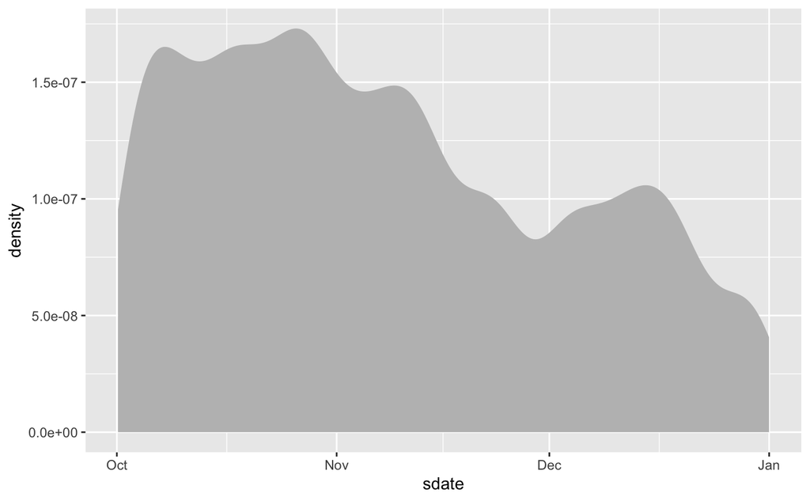

```r
Trips %>%
  ggplot(aes(x = sdate)) +
  geom_density(fill = "gray", color = NA)
```

# Section: How Long?

Make box & whisker plot showing the distribution of rental duration by client type. As instructed in the text, make sure you either configure your scale or use a filter to suppress outliers from dictating the axis range.

```r
Trips <-
  Trips %>%
  mutate(duration_mintutes  = as.numeric(edate - sdate)/60)
```

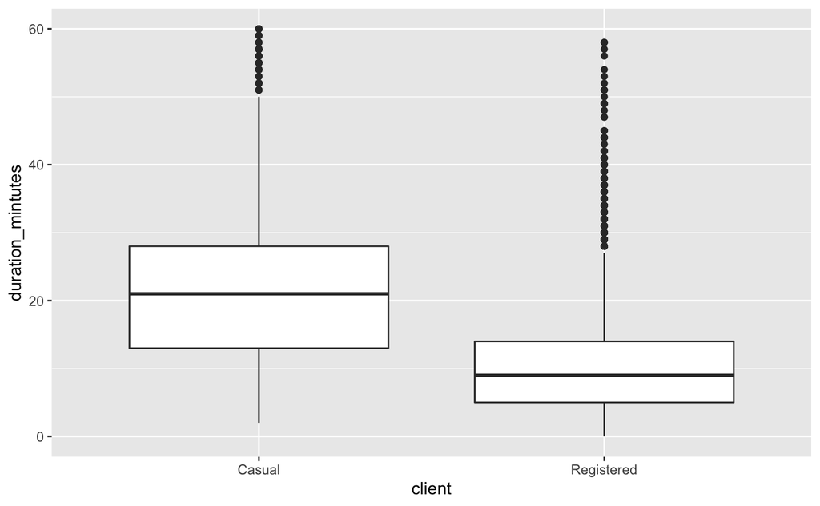

```r
Trips %>%
  ggplot(aes(x = client, y = duration_mintutes)) +
  geom_boxplot() +
  ylim(0, 60)
```

There are more number of registrered than casual clients.The box-scatter plot demonstrates that casual client have more duration in the range of 50-60 minutes than registered clients that took from all ranges 27-60.

# Section: When are bikes used?

Note: You’ll use several functions that begin with `lubridate::` this means that those functions have come from the `lubridate` R package, which makes it easy to work with dates in R. The activity template instructed you to load this package already, but you should use Google or the RStudio help to get a sense of the kind of things this package is designed to do.

```r
Trips <-
  Trips %>%
  mutate(dayofYear = lubridate::yday(sdate))
```

```r
Trips <-
  Trips %>%
  mutate(dayofweek = lubridate::wday(sdate))
```

```r
Trips <-
  Trips %>%
  mutate(hourofday = lubridate::hour(sdate))
```

```r
Trips <-
  Trips %>%
  mutate(mininhour = lubridate::minute(sdate))
```

##### Day of the year (1 to 365)

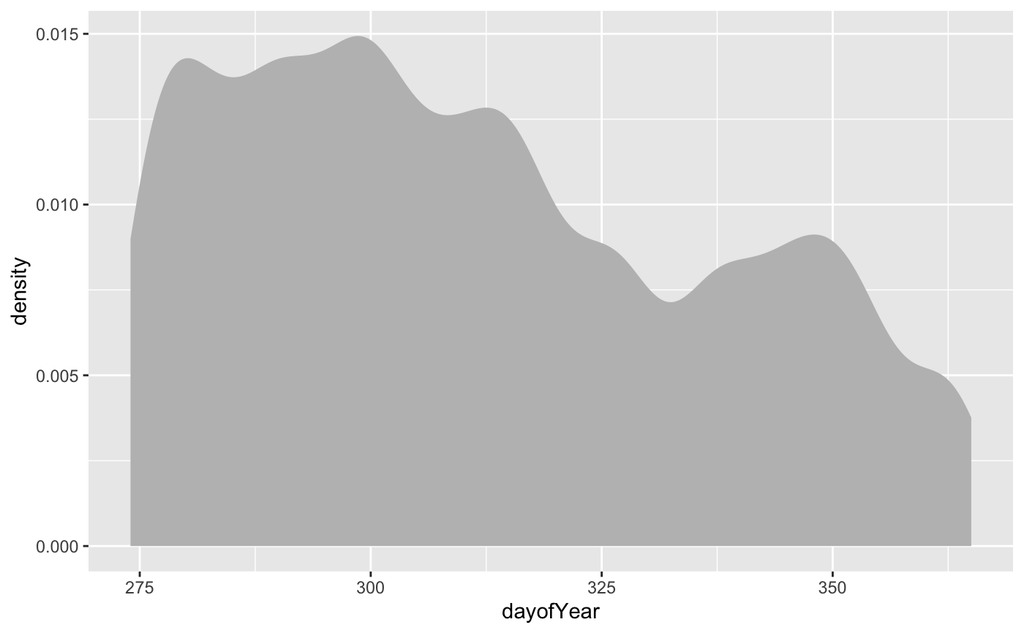

```r
Trips %>%
  ggplot(aes(x = dayofYear)) +
  geom_density(fill = "gray", color = NA)
```

##### Day of the week (Sunday to Saturday)

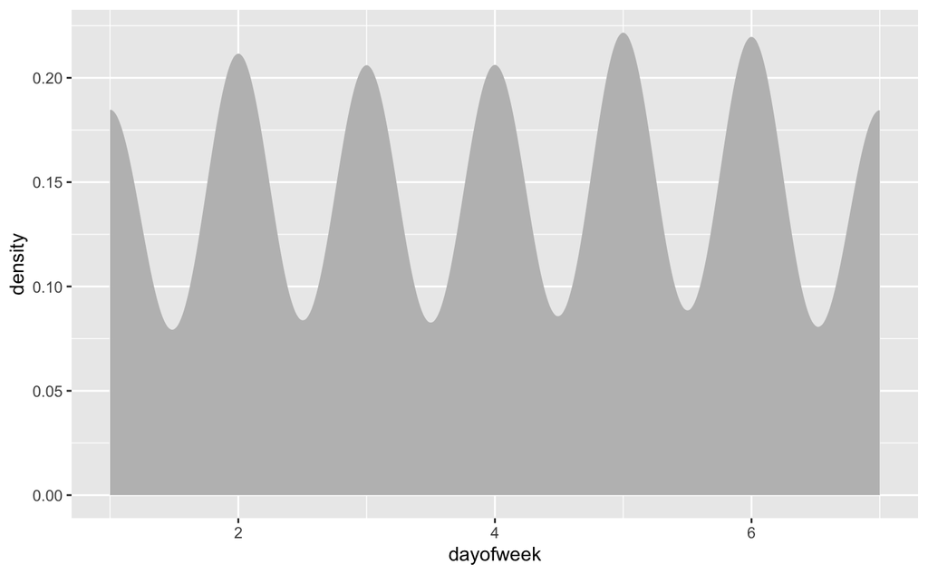

```r
Trips %>%
  ggplot(aes(x = dayofweek)) +
  geom_density(fill = "gray", color = NA)
```

The graph shows density of days of the week, all days have similiar frequency of users. So the number of bikes checked out are pretty much the same everyday.

##### Hour of the day (0 to 24)

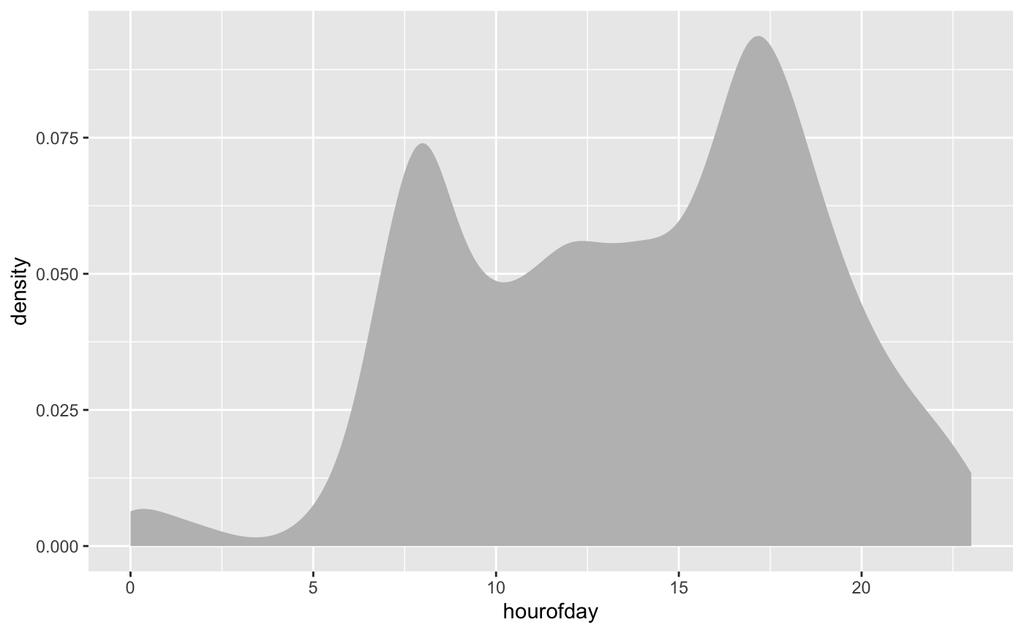

```r
Trips %>%
  ggplot(aes(x = hourofday)) +
  geom_density(fill = "gray", color = NA)
```

##### Minute in the hour (0 to 60)

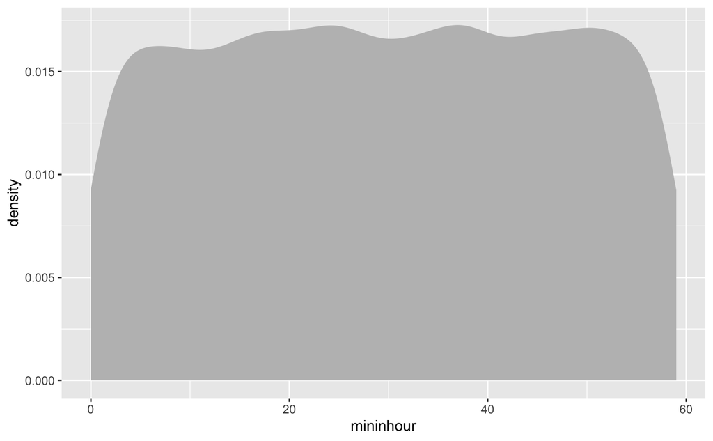

```r
Trips %>%
  ggplot(aes(x = mininhour)) +
  geom_density(fill = "gray", color = NA)
```

The graph shows density based upon minutes in an hour, where 10 - 50 high and consisten number of checkout and same with density/frequency.

### Group the bike rentals by hour, weekday, & client type

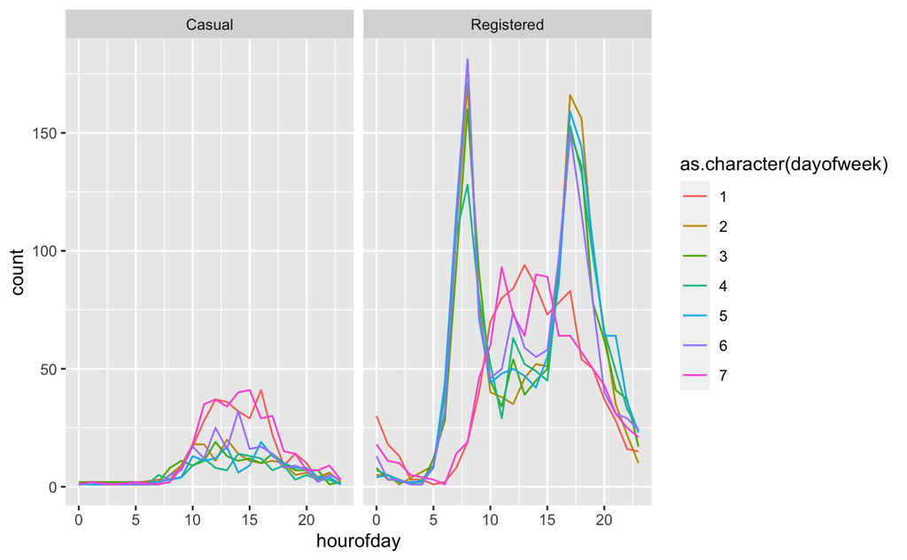

```r
Trips %>%
  group_by(client, dayofweek, hourofday) %>%
  summarise(count = n()) %>%
  ggplot(aes(x = hourofday, y = count)) +
  geom_line(aes(group = dayofweek, color = as.character(dayofweek))) +
  facet_wrap(~client)
```

There are more registered clients than occasional clients. And most casual customers take advantage of the afternoon to view the bikes, usually the first and seventh days of the week. Whereas the majority of registered clients show up in the morning or in the evening, and more on weekdays.

### Construct a similar plot using density rather than frequency

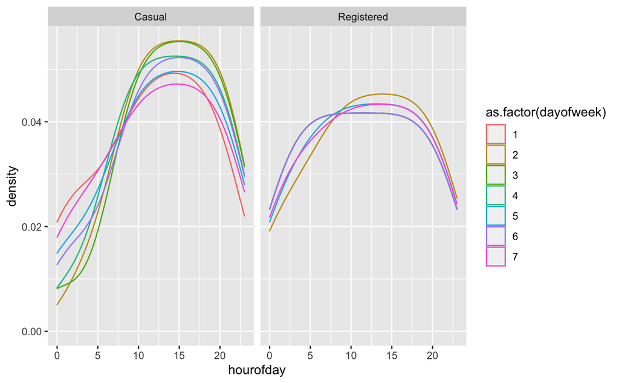

```r
Trips %>%
  group_by(client, dayofweek, hourofday) %>%
  summarise(count = n()) %>%
  ggplot(aes(x = hourofday)) +
  geom_density(aes(group = dayofweek, color=as.factor(dayofweek))) +
  facet_wrap(~client)
```

# Section: How Far?

We want to calculate the distance between stations using the `haversine()` function. The `source()` function actually runs an R script found at some URL. Use a web browser to visit this URL and read about the function (it’s only a few lines).

```r
source("https://mdbeckman.github.io/dcSupplement/R/haversine.R")

Simple <-
  Stations %>%
  select(name, lat, long) %>%
  rename(sstation = name)

Simple2 <-
  Simple %>%
  rename(estation = sstation, lat2 = lat, long2 = long)

head(Simple)
```

| sstation | lat | long |
| --- | --- | --- |
| 20th & Bell St | 38.85610 | -77.05120 |
| 18th & Eads St. | 38.85725 | -77.05332 |
| 20th & Crystal Dr | 38.85640 | -77.04920 |
| 15th & Crystal Dr | 38.86017 | -77.04959 |
| Aurora Hills Community Ctr/18th & Hayes St | 38.85787 | -77.05949 |
| Pentagon City Metro / 12th & S Hayes St | 38.86230 | -77.05994 |

```r
head(Simple2)
```

| estation | lat2 | long2 |
| --- | --- | --- |
| 20th & Bell St | 38.85610 | -77.05120 |
| 18th & Eads St. | 38.85725 | -77.05332 |
| 20th & Crystal Dr | 38.85640 | -77.04920 |
| 15th & Crystal Dr | 38.86017 | -77.04959 |
| Aurora Hills Community Ctr/18th & Hayes St | 38.85787 | -77.05949 |
| Pentagon City Metro / 12th & S Hayes St | 38.86230 | -77.05994 |

```r
StationPairs <- merge(Simple, Simple2, by = NULL)
head(StationPairs)
```

|  | sstation | lat | long | estation | lat2 | long2 |
| --- | --- | --- | --- | --- | --- | --- |
| 1 | 20th & Bell St | 38.85610 | -77.05120 | 20th & Bell St | 38.8561 | -77.0512 |
| 2 | 18th & Eads St. | 38.85725 | -77.05332 | 20th & Bell St | 38.8561 | -77.0512 |
| 3 | 20th & Crystal Dr | 38.85640 | -77.04920 | 20th & Bell St | 38.8561 | -77.0512 |
| 4 | 15th & Crystal Dr | 38.86017 | -77.04959 | 20th & Bell St | 38.8561 | -77.0512 |
| 5 | Aurora Hills Community Ctr/18th & Hayes St | 38.85787 | -77.05949 | 20th & Bell St | 38.8561 | -77.0512 |
| 6 | Pentagon City Metro / 12th & S Hayes St | 38.86230 | -77.05994 | 20th & Bell St | 38.8561 | -77.0512 |

```r
PairDistances <-
  StationPairs %>%
  mutate(distance = haversine(lat, long, lat2, long2)) %>%
  select(sstation, estation, distance)
```

```r
Merged_Trip_Distance <-
  PairDistances %>%
  inner_join(Trips)
```

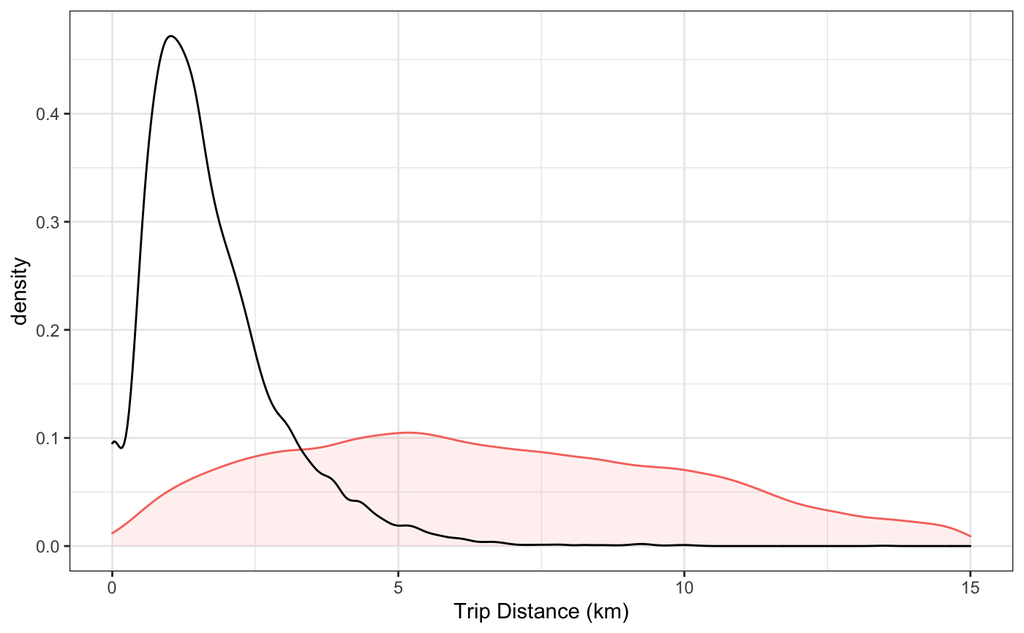

```r
PairDistances %>%
  ggplot(aes(x = distance))+
  geom_density(aes(color = 'pink',fill = 'pink', alpha = '.7'))+
  geom_density(data = Merged_Trip_Distance)+
  xlim(0,15)+
  xlab('Trip Distance (km)')+
  theme_bw()+
  theme(legend.position = "none")
```

# Section: Mapping the Stations

```r
library(leaflet)
stationMap <-
  leaflet(Stations) %>%           # like ggplot()
  addTiles() %>%                  # add the map
  addCircleMarkers(radius = 2, color = "red") %>%
  setView(-77.04, 38.9, zoom = 12)
```

```
Assuming "long" and "lat" are longitude and latitude, respectively
```

```r
stationMap
```

[interactive chart not shown]

```r
median(Trips$distance)/3
```

```
numeric(0)
```

Red circles are where bikes have been taken.

# Section: Long-distance stations (Extra Credit)

```r
library(leaflet)
stationMap <-
  leaflet(Stations) %>%
  addTiles() %>%
  addCircles(radius = 487, color = "blue", opacity = 0.0001)%>%
  setView(-77.04, 38.9, zoom = 12)
```

```
Assuming "long" and "lat" are longitude and latitude, respectively
```

```r
stationMap
```

[interactive chart not shown]

```r
median(Trips$distance)/3
```

```
numeric(0)
```